#### **To: Quian Xu**

#### **From: Anh Nguyen (Yumi), Miguel Gonzalez**

#### **Date: 11/02/2019**

#### **RE:Cereal Analysis**

Dear Quian,

My teammate, Yumi, and I have come across some interesting findings with the dataset you provided: competitor’s strategy, optimal sales, and popularity among flavors.

Cereal is one of America’s most popular meals, whether it’s for the kids weekday breakfast, dad’s favorite flakes, or grandma’s usual. We see cereals on almost every home’s cabinet. When our customers go to the aisles, they usually know what they want. It is important for us to follow our customers’ behavior to sustain that relationship and continue to make more families happy.

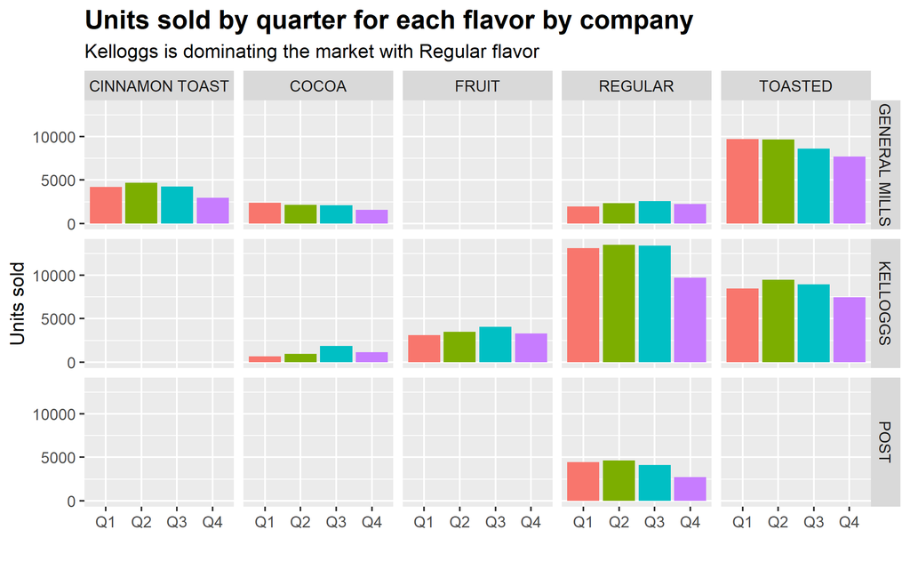

With this, we investigated more on whether having ads plays a part of the units sold. Base on the data set, we know that GM ran a total of **7189** ads throughout the year while Kelloggs ran almost double with a total of **12183** ads. We also noticed that there is a relationship between having ads and units sold:

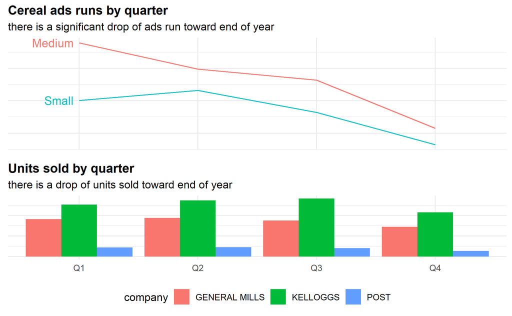

We can see there is a slight drop in Q4 in cereal sales and a bigger drop in advertisements for all companies. Could it be that cereal is less desired during the holidays? Or ads are more expensive to run during those 3 months?

Since Kelloggs takes most of the pie for Regular like we previously discovered, we dug deeper into their pricing with and without promotion and compared it with our company’s pricing:

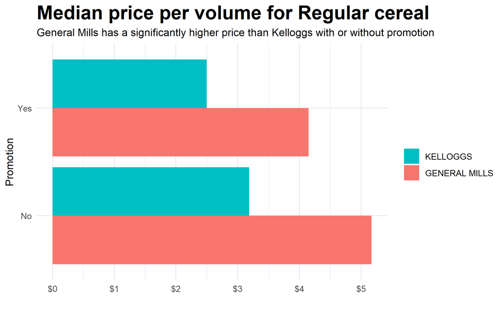

GM’s median price per volume for flavor Regular is significantly higher than Kelloggs’. We currently stand at **$5** per volume while Kelloggs has theirs at **$3** per volume. Even with promotions, our price is still higher than Kelloggs’s normal price. That explains the higher units sold on Regular flavor for Kelloggs than GM.

We would like to request more data, including the unit cost and more information regarding the stores. This can be crucial to target ads by location.

Please do not hesitate to contact us if you have questions or would like to discuss the analysis further, it is best to reach us at theanalystgroup@seattleu.edu

Best regards,

Miguel & Yumi  
Data Analyst II